# Data Verbs

In English grammar, a verb is a word that expresses an action.[^1] In working with data, a verb is a function that transfigures a data table in some specified way.

The word “transfigure” is used intentionally. A data verb turns a data table into a new data table. The new data table may have the same kinds of cases as the original, or it may have different kinds of cases. For instance, data verbs can be used to transfigure a data table with cases about individual people (each living in a country) into a data table where the cases are countries.

The basic data verbs you will study in these notes[^2] are:

- `summarise()`
- `group_by()`

Keep these things in mind about data-verb functions:

- The data-verb function **always** takes a data table as an input.
- The data-verb function takes other arguments that specify the details of the transfiguration.
- The data-verb function **never** changes the input data table. Instead it returns a new data table. You can use assignment to store that table. (If you assign the output to the same name as the input, the new value will overwrite the old.)
- Since data-verb functions take a data table as input and produce a data table as a return value, it’s natural to construct complex transfigurations by *chaining* a sequence of verbs together.

## Summarise

The `summarise()` data verb[^3], calculates values that combine the cases in a specified way. Common calculations include:

- `n()` — counts the cases.
- `sum()`, `mean()`, `median()`, `sd()` — summarizes of a numerical variable.
- `max()`, `min()` — finds maxima and minima of numerical variable.

To illustrate the uses of `summarise()`, consider the `WorldCities` data table (in the `DCFdevel` package).

```r
data( WorldCities,package="DCFdevel" )
names( WorldCities )
```

```
 [1] "Code"          "Name"          "Latitude"
 [4] "Longitude"     "Country"       "CountryRegion"
 [7] "Population"    "RegionCode"    "Region"
[10] "Date"
```

```r
# DELETE THIS LINE BELOW AFTER FIXING THE DCF PACKAGE dataframe
WorldCities <- mutate(WorldCities, Population=as.numeric(Population))
```

This consists of 23,018 of the most populous cities in the world.

To see this, we can summarize the cases with a simple count. That is:

```r
WorldCities %>%
  summarise( count=n() )
```

```
  count
1 23018
```

Perhaps you want to know the total population in these cities, or the average population per city or the smallest city in the table.

```r
WorldCities %>%
  summarise( averPop=mean(Population),
             totalPop=sum(Population),
             smallest=min(Population) )
```

```
  averPop  totalPop smallest
1  112625 2.592e+09        0
```

EXERCISE:

Find the location of

- the most northern and most southern city. The city closest to
- the equator.

END OF EXERCISE.

The average city on the list has about 110,000 people. The total population of people living in these cities is about 2.6 billion — a bit more than one-third of the world population. The smallest city has — this seems strange! — zero people; not really a city at all.

Some things to notice about the use of `summarise()`:

- The chaining syntax, `%>%` has been used to pass the first argument to `summarize()`. This will be useful later on, when there is more than one step in a transfiguration. It’s OK to *end* a line with `%>%`, but **never** start a line with it.
- The output of `summarize()` is a data table. True, there is only one case in the output of the example: “all cities.” The `summarise()` function aggregates over the cases in the input data — the output therefore has a different meaning for case.
- Named assignment has been used to give names to the variables in the output data.frame.

## Group_by

The `group_by()` data verb sets things up so that other data verbs will perform their action on a group-by-group basis. For instance:

```r
WorldCities %>%
  group_by( Country ) %>%
  summarise( count=n() ) %>% head
```

```
Source: local data frame [6 x 2]

  Country count
1      AD     2
2      AE    12
3      AF    50
4      AG     1
5      AI     1
6      AL    20
```

The transfiguration produced by `group_by()` is very subtle. You won’t notice it unless you perform some other action on the output of `group_by()`; it really just marks the data table as being grouped and arranges the its structure to be as efficient as possible for those other operations.

Using `group_by()` along with `summarize()` and `n()`, provides a basis for counting up the number of cases in groups and subgroups, or for calculating group-wise statistics.

Note that the functions used within `summarise()` — `n()`, `max()`, `sum()`, etc. — are **not** data verbs. Remember that a data verb takes a data table as input and returns a transfigured data table as output. In contrast, the summary functions, `n()`, `sum()`, and so on, take a set of numbers as input and return a *single number* as output. The `summarise()` function will take insert these numbers from the summary function into the output dataframe

## Is That All?

`Summarise()` is a team player; it works best in combination with other data verbs. Once you learn those data verbs, particularly `filter()` and `mutate()`, you’ll be able to carry out many more operations. The richness of the data-verb system comes from the ways the different verbs can be combined together. With just `group_by()` and `summarize()` you will be very limited.

### EXERCISE

SIMPLE, SIMPLE: `NA` is a fact of life. Using `na.rm=TRUE` when the result of a computation is `NA`. Explaining what `NA` means. `is.na()`.

SIMPLE, SIMPLE: levels of categorical variables, e.g. ‘alive’ versus ‘Alive’ in `NHANES`.

Use `==` and `mean()` to find the proportion of cases at a given level, e.g. what fraction of smokers have died. Here’s an example of the syntax you’ll need, using `sex` instead of `smoker`.

```r
data(NHANESDCF, package="DCFdevel")  # CHANGE THIS LINE TO data(NHANES)
NHANES %>% group_by( sex ) %>%
  summarise( living=mean( death=='alive', na.rm=TRUE ))
```

```
Source: local data frame [2 x 2]

     sex living
1 Female 0.9356
2   Male 0.9064
```

Add in: Look carefully at the quantity being given to `mean()`. The variable name is `death`. Since it’s a variable name, there are no quotes around it. The `==` tests of equality. The quoted string, `"alive"`, is one of the levels of the categorical variable `death`. Altogether, `mean( death=="alive" )` means “the proportion of cases still alive.”[^4]

Then break down by smoker, etc. as the exercise. Don’t show them this, but ask them to draw conclusions: which group is more likely to be alive.

```r
NHANES %>% group_by(smoker) %>%
  summarise( count=n(),
             living=mean(death=="alive", na.rm=TRUE) )
```

```
Source: local data frame [3 x 3]

     smoker count living
1 nonsmoker 15984 0.9214
2    smoker  4161 0.9343
3        NA 10981 0.8970
```

```r
NHANES %>% group_by(sex, smoker) %>%
  summarise( living=mean(death=="alive", na.rm=TRUE) )
```

```
Source: local data frame [6 x 3]
Groups: sex

     sex    smoker living
1 Female nonsmoker 0.9407
2 Female    smoker 0.9452
3 Female        NA 0.8881
4   Male nonsmoker 0.8978
5   Male    smoker 0.9261
6   Male        NA 0.9090
```

Then, ask them to break it down by people over 60 and people under 60.

```r
NHANES %>% group_by(age<=60,sex, smoker) %>%
  summarise( living=mean(death=="alive", na.rm=TRUE) )
```

```
Source: local data frame [12 x 4]
Groups: age <= 60, sex

   age <= 60    sex    smoker living
1      FALSE Female nonsmoker 0.8439
2      FALSE Female    smoker 0.7708
3      FALSE Female        NA 0.7003
4      FALSE   Male nonsmoker 0.7677
5      FALSE   Male    smoker 0.7285
6      FALSE   Male        NA 0.6706
7       TRUE Female nonsmoker 0.9904
8       TRUE Female    smoker 0.9750
9       TRUE Female        NA 0.9953
10      TRUE   Male nonsmoker 0.9813
11      TRUE   Male    smoker 0.9671
12      TRUE   Male        NA 0.9792
```

Among the young males, which group is more likely to be alive: smokers or non-smokers. How about among older males? Young females? Older females?

Explain something about Simpson’s paradox.

Another EXERCISE …

Make a stacked bar chart of proportions for each of the smoking, sex, age groups. Use this to illustrate the different kinds of plots.

Another EXERCISE …

Using `ntile()` to convert quantitative to categorical. List some of the other converters, e.g., `cut()`.

### An example

To illustrate, consider the NHANES data containing body shape, health, and mortality information. The case is an individual person.

```r
data(NHANESDCF)
```

One of the variables is `HDL` — [HDL cholesterol](http://www.mayoclinic.org/diseases-conditions/high-blood-cholesterol/in-depth/hdl-cholesterol/art-20046388). (HDL is the “good” kind of cholesterol, as opposed to LDL cholesterol, which is reported in the `LDL` variable).

Suppose you want to know a typical HDL level. “Typical” is with respect to the values for all the cases, not just the value for a single case. Since all the cases are being combined, `summarize()` is appropriate.

```r
NHANES %>%
  group_by( sex ) %>%
  summarise( typical=mean( HDL, na.rm=TRUE ),
             shortest=min( height, na.rm=TRUE ),
             n=n() )
```

```r
NHANES %>% summarise( typical=mean( HDL, na.rm=TRUE ) )
```

```
  typical
1   52.37
```

Or, perhaps you want the typical HDL, the shortest height, and the number of cases.

```r
NHANES %>%
  summarise( typical=mean( HDL, na.rm=TRUE ),
                      shortest=min( height, na.rm=TRUE ),
                      count=n() )
```

```
  typical shortest count
1   52.37     0.79 31126
```

- Each of the numerical calculations has been instructed to ignore missing data. Without this, the missing data shapes the result:

  ```r
  NHANES %>% summarise( typical=mean( HDL ),
                    shortest=min( height ))
  ```

  ```
    typical shortest
  1     NaN      NaN
  ```

- The `n()` function doesn’t need to be passed a variable. All of the variables in a data table have the same number of cases.

## Group_by

The `group_by()` data verb sets things up so that other data verbs will perform their action on a group-by-group basis. For instance:

```r
NHANES %>%
  group_by( sex ) %>%
  summarise( typical=mean( HDL, na.rm=TRUE ),
             shortest=min( height, na.rm=TRUE ),
             n=n() )
```

```
Source: local data frame [2 x 4]

     sex typical shortest     n
1 Female   55.70    0.797 15942
2   Male   48.91    0.790 15184
```

Using `group_by()` along with `summarize()` and `n()`, provides a basis for counting up the number of cases in groups and subgroups:

```r
NHANES %>%
  group_by( sex, smoker ) %>%
  summarize( n=n() )
```

```
Source: local data frame [6 x 3]
Groups: sex

     sex    smoker    n
1 Female nonsmoker 8558
2 Female    smoker 1815
3 Female        NA 5569
4   Male nonsmoker 7426
5   Male    smoker 2346
6   Male        NA 5412
```

## EXERCISES:

### One

What does this do?

```r
NHANES %>%
  group_by( sex, smoker ) %>%
  summarize( n=n() )
```

### Two

Maybe in this section, mean BP for smokers and non-smokers.

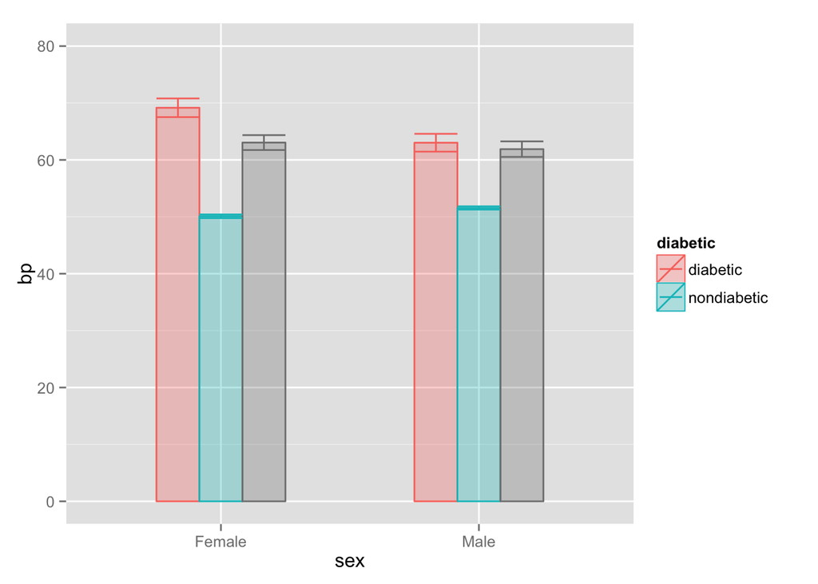

```r
group_by(NHANES, sex, diabetic) %>%
  summarize(bp=mean(systolic-diastolic,na.rm=TRUE),n=n(),
                                              se=sd(systolic-diastolic, na.rm=TRUE)/sqrt(n)) -> foo
ggplot(foo, aes(x=sex, group=diabetic, color=diabetic,y=bp,width=.5))  + geom_bar(alpha=.3,aes(fill=diabetic),position='dodge',stat='identity') + geom_errorbar(aes(ymax=bp+2*se,ymin=bp-2*se,),position='dodge')  + ylim(0,80)
```

For errorbars and such, you need to use `position=position_dodge(width=.5)` to separate the groups equally.

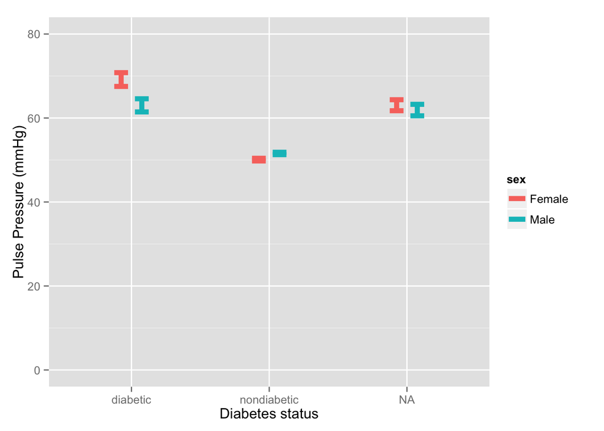

```r
ggplot(foo, aes(group=sex, x=diabetic, y=bp,width=.5))  +
#  geom_bar(alpha=.3,aes(fill=sex),position='dodge',stat='identity') +
  geom_errorbar(aes(ymax=bp+2*se,ymin=bp-2*se,color=sex),
                position=position_dodge(width=0.3),weight=3,size=2,width=.2)  +
  ylim(0,80) + ylab("Pulse Pressure (mmHg)") +
  xlab("Diabetes status")
```

QUESTIONS TO ASK: * What variables are here? * What cases are here in the glyph-ready data? * Which variable is represented by color? * Which variable sets th position of the subgroup w.r.t. the overall group? * The length of the error bars reflects a quantity called the “standard error”.

Make graphs to compare diabetics to non-diabetics in each group, and to compare males to females in each group.

Perhaps jazz it up with age-group.

## What fraction are diabetic in the various age groups

```r
mutate(NHANES, AgeGroup=ntils(age,n=10,format='left')) %>%
  group_by(sex,AgeGroup) %>%
  summarize(dfrac=mean(diabetic=='diabetic',na.rm=TRUE),
            se=sqrt(dfrac*(1-dfrac)/length(diabetic)) )-> hoo
ggplot(hoo, aes(x=AgeGroup,y=dfrac,group=sex)) + geom_bar(alpha=.3,aes(fill=sex,color=sex),position='dodge',stat='identity',width=4) + geom_errorbar(aes(ymax=dfrac+se,ymin=dfrac-se,color=sex),position='dodge')
```

### Proportion with summarize:

The point here is that once you’ve reduced the data to a tally of each group, you want to keep those cases, so you want a mutate(). But even in `mutate()`, aggregation operators work over the whole group.

```r
group_by(NHANES, sex, smoker, diabetic) %>% tally() -> tmp
# get rid of the NA here
filter(tmp, diabetic != 'NA' & smoker != 'NA') %>%
mutate( total=sum(n),frac=n/total) %>% filter( diabetic=='diabetic')
```

```
Source: local data frame [4 x 6]
Groups: sex, smoker

     sex    smoker diabetic   n total    frac
1 Female nonsmoker diabetic 598  8471 0.07059
2 Female    smoker diabetic 114  1796 0.06347
3   Male nonsmoker diabetic 577  7344 0.07857
4   Male    smoker diabetic 142  2330 0.06094
```

## Create a proportion function

Do I want this?

```r
simple <- function(v) {
  sum(v,na.rm=TRUE)/length(v)
}
proportion <- function(.data,...) {
  do(.data,data.frame(prop.table(do.call(table,select(.,...)))))
}
# example
# group_by(NHANES,sex,smoker) %>% proportion(diabetic)
```

## TO DO

- Fix NHANES to turn `NaN` into `NA` in the numerical variables.
- Set the option `"na.rm"` to `TRUE` when the DCF package is loaded.
- Have earlier examples with `summary()` of a single variable:

  ```
  with( NHANES, summary(height) )
  ```

  That will let you show what the variables look like. Or maybe show a boxplot.

## Returned values, arguments, inputs and outputs

Explain what these are.

Also, assignment. Use `<-` to distinquish between assignment and named arguments. `<-` gives the output of a function to a name, or, in other words, “assigns a value to an object named …”

For each sex and smoker group, what fraction has diabetes?

```r
group_by(NHANES,sex,smoker) %>% mutate(count=n()) -> tmp
summarize(tmp, sum(diabetic=='diabetic')/count )
dcast(group_by(NHANES,sex,smoker) %>% proportion(diabetic),
      ~diabetic,value.var='Freq')
tmp <- group_by(NHANES,sex) %>% summarize( k=sum(diabetic=='diabetic') )
ggplot(tmp, aes(x=sex,y=n,fill=smoker)) +
  geom_bar(stat='identity',position='fill')
```

## Transforms and Aggregations

An important distinction to make in using data is between **transforming** and **aggregating**.

In aggregating data, you will be combining cases. Think of aggregating as creating a new kind of case.

In transforming data, you will be treating each and every case individually.

```r
pulse <- with( NHANES, systolic-diastolic )
```

This subtraction is a transform. It produces a result for each case in NHANES, all 31126 of them.

```r
summary( pulse )
```

```
   Min. 1st Qu.  Median    Mean 3rd Qu.    Max.    NA's
     10      39      48      52      60     208    9052
```

In contrast, suppose you want to know the median diastolic pressure. That’s an aggregation. It converts the whole set of cases into a single number.

```r
with( NHANES, median(diastolic))
```

```
[1] NA
```

There are many possible transforms and many different aggregations. Here are a few:

- **Transforms**: arithmetic operations (`+`, `-`, `*`, `/`, `^`), `sqrt()`, `log()`, and so on.
- **Aggregations**: `mean()`, `median()`, `sum()`, `range()`, `sd()`, `IQR()` and so on.

Remember: a transformation keeps each case as it is, while an aggregation produces a new sort of case. In `NHANES` or transformations of it, the case is an individual person. In an aggregation of `NHANES` the case is “all the people together.”

## What you give should be what you get

As you’ve seen, data are organized into data frames. A useful style in computing is to arrange computations so that the input is a data frame and the output is also a data frame. When things are set up this way, you can easily use the output of one computation as the input to another. For instance, you may want to transform variables before plotting them.

To support this style, you’ll be using specific functions: `mutate()`, `summarize()`, `group_by()` and so on. If you have used R before, these functions may be unfamiliar. And, of course, if you have never used R, the functions are new to you.

### Transforms

To perform a transform, use the `mutate()` function. The first argument is a data frame. Additional arguments specify the transform to be calculated. Like this:

```r
output <- mutate( NHANES, pulse=systolic-diastolic )
```

In this operation, a new variable has been created called `pulse`. The output copies over the input data frame as well, so `output` will have all the variables originally in `NHANES` along with `pulse`:

```r
names(output)
```

```
 [1] "sex"        "height"     "weight"     "age"
 [5] "BMI"        "trunkfat"   "leanBMI"    "LDL"
 [9] "HDL"        "systolic"   "diastolic"  "income"
[13] "pregnant"   "death"      "followup"   "smoker"
[17] "diabetic"   "framingham" "percentfat" "pulse"
```

A very common style with a transform is to use the output of `mutate()` to redefine the input data frame, as with:

```r
NHANES <- mutate( NHANES, pulse=systolic-diastolic )
```

Sometimes, you will use a transform to modify an existing variable. For instance, the `followup` variable in `NHANES` gives — for those people who died soon after the study — the number of months from the initial measurements until the subject died. Perhaps you want this in years rather than months.

```r
NHANES <- mutate( NHANES, followup=followup/12 )
```

### Aggregation

To carry out an aggregation, use the `summarize()` function.

```r
summarize( NHANES, typicalAge=median(age, na.rm=TRUE) )
```

```
  typicalAge
1         19
```

The output of `summarize()` is a data frame, albeit a very short data frame in this situation.

Sometimes, you will want to use an aggregate quantity as part of a transformation. Suppose, for instance, that you want to know how much each person differs in height from the mean.

```r
NHANES <- mutate( NHANES, hgtDiff=height-mean(height) )
```

```r
summarize( NHANES, mean(height), mean(hgtDiff))
```

```
  mean(height) mean(hgtDiff)
1          NaN           NaN
```

## Grouping

Often, you will be interested in studying **groups** of cases, for instance the males and females in `NHANES` or the smoking diabetics versus non-smoking diabetics.

In order to do the grouping, you need one or more variables that specify the groups, for instance, `sex`, `diabetic`, and `smoker` in NHANES. Use the `group_by()` function to specify which variables you want to use.

Grouping cases doesn’t in itself do anything. Instead, grouping sets things up so that `summarize()`, `mutate()`, and some other functions can do things on a group-by-group basis. Example:

```r
NHANES <- group_by( NHANES, sex )
summarize( NHANES, typicalAge=median(age, na.rm=TRUE) )
```

```
Source: local data frame [2 x 2]

     sex typicalAge
1 Female         20
2   Male         19
```

Doing a transform on a grouped variable allows you, if you want, to use aggregate quantities for that group. For instance, the groups of males and females have different mean heights. Here’s how you would calculate the difference of an individual from his or her group’s mean.

```r
NHANES <- group_by( NHANES, sex )
NHANES <- mutate( NHANES, dheight=height-mean(height) )
summarize( NHANES, sd(dheight) )
```

```
Source: local data frame [2 x 2]

     sex sd(dheight)
1 Female         NaN
2   Male         NaN
```

### NOTE: For proportion …

```r
group_by(NHANES, sex,smoker) %>% summarize(pd=mean(diabetic=='diabetic',na.rm=TRUE),sz=n(),se=sqrt(pd*(1-pd)/sqrt(sz)))
```

```
Source: local data frame [6 x 5]
Groups: sex

     sex    smoker      pd   sz      se
1 Female nonsmoker 0.07059 8558 0.02663
2 Female    smoker 0.06347 1815 0.03735
3 Female        NA 0.02015 5569 0.01627
4   Male nonsmoker 0.07857 7426 0.02898
5   Male    smoker 0.06094 2346 0.03437
6   Male        NA 0.01125 5412 0.01230
```

## How Many?

n() and groupwise n(). n() takes no arguments because it wouldn’t matter which variable you used: they all have the same length

## Style

As mentioned before, re-using a name can make your commands easier to read.

Reassignment of the output to the input data frame may make sense for a transform. But it is generally a bad idea for an aggregation. (Explain why. Hint: What are the cases in the input and output.) [Show a reassignment in a summarize() and say DON’T DO THIS!]

## Example: Blood pressure and diabetes

The NHANES data gives … for 31000 people. Suppose you are interested in the question, does pulse pressure differ for diabetics and non-diabetics.

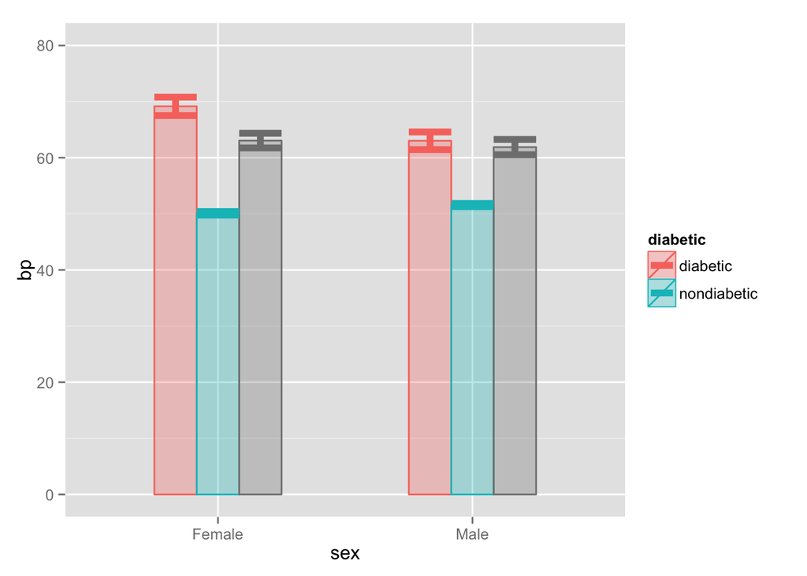

```r
group_by(NHANES, sex, diabetic) %>%
  summarize(bp=mean(systolic-diastolic,na.rm=TRUE),n=n(),
                                              se=sd(systolic-diastolic, na.rm=TRUE)/sqrt(n)) -> foo
ggplot(foo, aes(x=sex, group=diabetic, color=diabetic,y=bp,width=.5))  + geom_bar(alpha=.3,aes(fill=diabetic),position='dodge',stat='identity') + geom_errorbar(aes(ymax=bp+2*se,ymin=bp-2*se,),position='dodge',weight=3,size=2)  + ylim(0,80)
```

Perhaps a better plot would be:

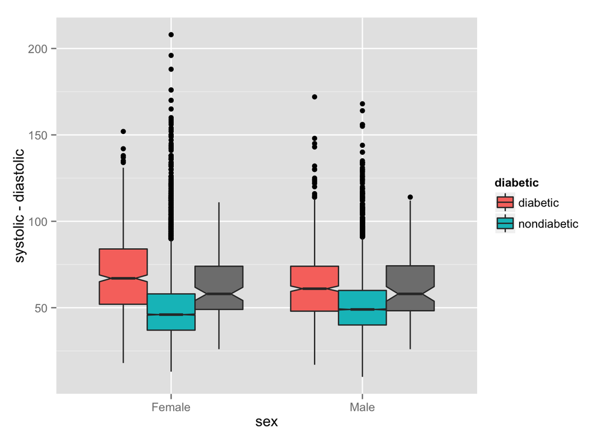

```r
ggplot(NHANES, aes(x=sex, y=systolic-diastolic, fill=diabetic)) + geom_boxplot(notch=TRUE)
```

NB. For some reason, geom_box() doesn’t use group. But color works.

MAYBE ALWAYS DO A SELECT to highlight the variables being used.

## Exercises

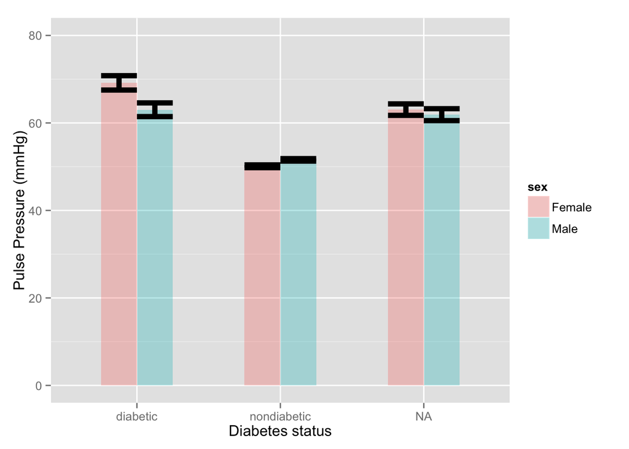

```r
group_by(NHANES, sex, diabetic) %>%
  summarize(bp=mean(systolic-diastolic,na.rm=TRUE),n=n(),
                                              se=sd(systolic-diastolic, na.rm=TRUE)/sqrt(n)) -> foo
ggplot(foo, aes(group=sex, x=diabetic, y=bp,width=.5))  + geom_bar(alpha=.3,aes(fill=sex),position='dodge',stat='identity') + geom_errorbar(aes(ymax=bp+2*se,ymin=bp-2*se,),position='dodge',weight=3,size=2)  + ylim(0,80) + ylab("Pulse Pressure (mmHg)") +
  xlab("Diabetes status")
```

ANS: Group by diabetes status rather than sex. Kill the NAs.

See [this set of exercises](http://www.public.iastate.edu/~hofmann/stat480/homework/dplyr%20drills.html)

## Still to do

Do a tabulation of the rank-choice data.

Find the variances of the NCI data, by probe.

Cross-tab of NHANES: perhaps cardiac death versus sex or BMI.

## MORE DATA POSSIBILITIES

Move these to the resources file when you have a chance.

Storm damage database: http://rpubs.com/deflath/20484

US Housing database: http://www.asdfree.com/2014/06/analyze-american-housing-survey-ahs.html

[^1]: And, to be more complete, a state of being. But that isn’t relevant here.
[^2]: Other data verbs are `filter()`, `mutate()`, `arrange()`, `join()`, `gather()`, and `spread()`
[^3]: Also known by the American spelling, `summarize()`
[^4]: Admittedly, it’s a bit odd to have a variable named `death` that can have a value `"alive"`. In the NHANES data, `death` indicates whether or not the person died, and whether the death (if any) was from cardiovascular causes.